# Video_games

### load games data and change data type for percentage column

```r
games <- readr::read_csv('https://raw.githubusercontent.com/rfordatascience/tidytuesday/master/data/2021/2021-03-16/games.csv')
games<-as.data.frame(games)
games[,7]<-as.numeric(sub("%", "", games[,7]))
dim(games)
```

```
## [1] 83631     7
```

In this dataset, there are 83631 games, each with 7 variables

### Check if there’s any missing data

```r
ix.na<- which(rowSums(is.na(games))>0)
dim(games[ix.na,])
```

```
## [1] 1364    7
```

1364 games contain missing data.

### Remove lines with missing data

```r
games.clean<-games[-ix.na,]
dim(games.clean)
```

```
## [1] 82267     7
```

After remove games with missing data. 82267 games are retained.

### Create summary statistics for serval variables

```r
summary(games.clean[,4:7])
```

```
##       avg                 gain                peak         avg_peak_perc
##  Min.   :      0.0   Min.   :-250249.0   Min.   :      1   Min.   : 0.00
##  1st Qu.:     53.9   1st Qu.:    -38.3   1st Qu.:    139   1st Qu.:34.63
##  Median :    203.1   Median :     -1.6   Median :    499   Median :43.90
##  Mean   :   2749.3   Mean   :    -10.3   Mean   :   5419   Mean   :42.58
##  3rd Qu.:    756.0   3rd Qu.:     22.3   3rd Qu.:   1706   3rd Qu.:51.39
##  Max.   :1584886.8   Max.   : 426446.1   Max.   :3236027   Max.   :88.84
```

Somes descriptive statistics are provided for above four numerical variables.

### Create histogram to characterize the distribution of key variables

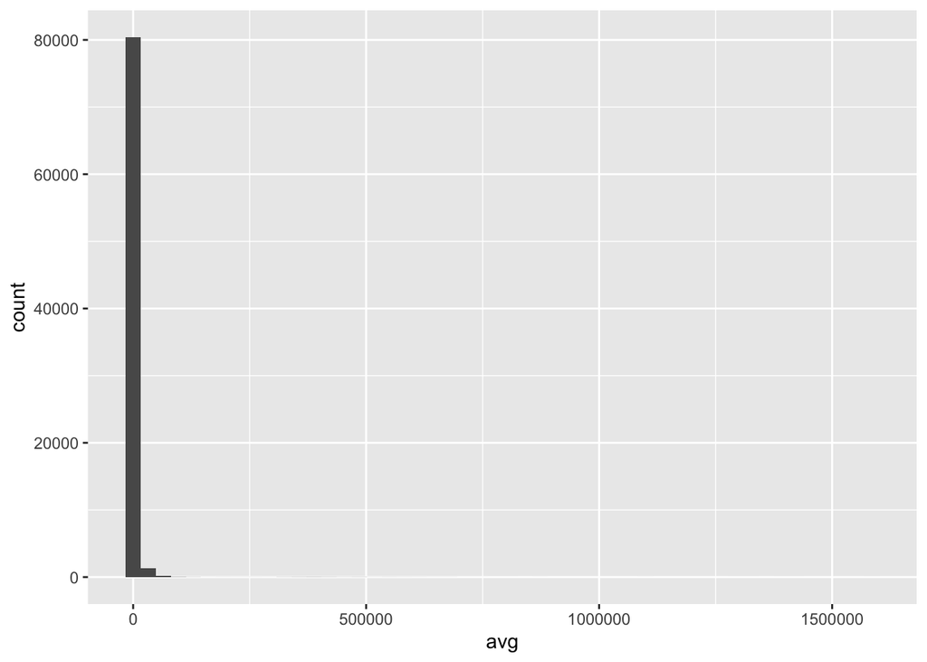

```r
#histogram for avg
library(ggplot2)
ggplot(games.clean, aes(x=avg)) + geom_histogram(bins=50)
```

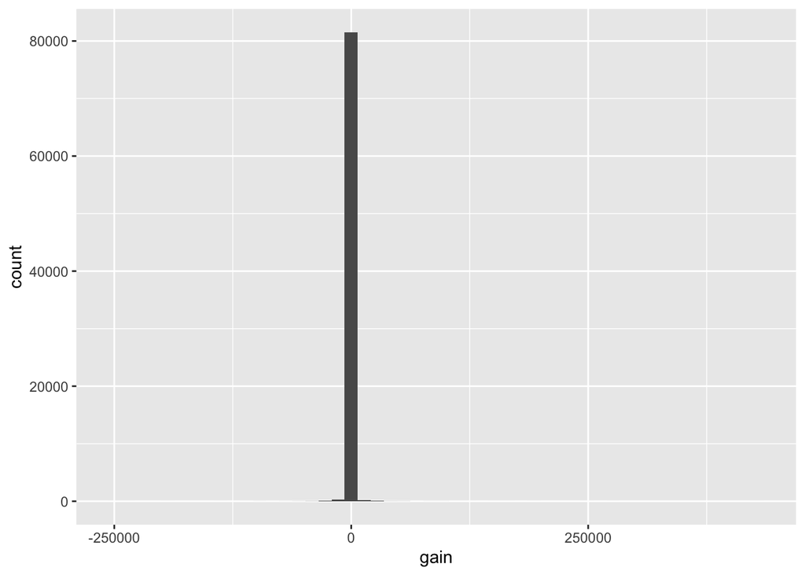

```r
#histogram for gain/loss
ggplot(games.clean, aes(x=gain)) + geom_histogram(bins =50)
```

For most games, gains compared to previous month is 0.

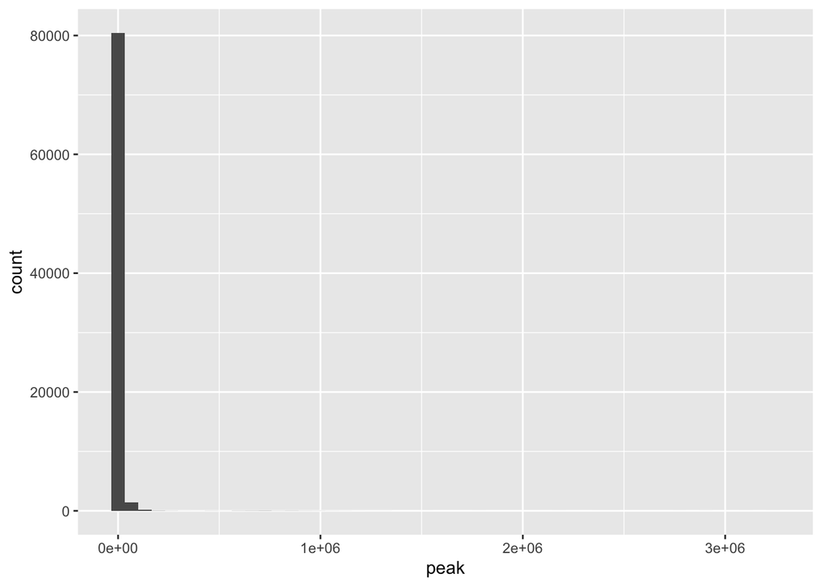

```r
#histogram for peak
ggplot(games.clean, aes(x=peak)) + geom_histogram(bins =50)
```

```r
library(dplyr)
```

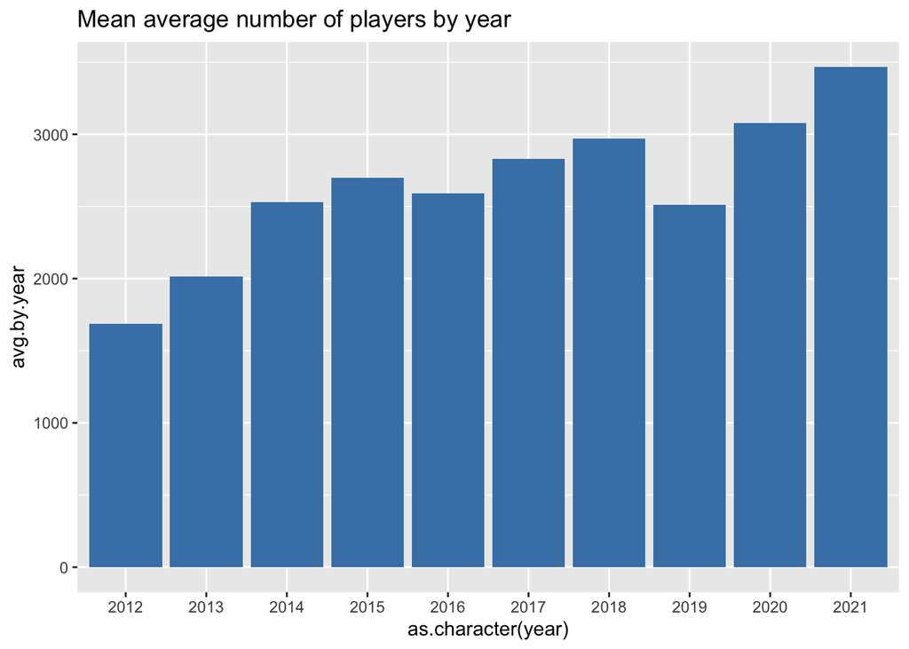

```r
grouped.year<-group_by(games.clean,year)
avg_by_year<-summarise(grouped.year,
          avg.by.year=mean(avg))
p<-ggplot(data=avg_by_year, aes(x=as.character(year), y=avg.by.year)) +
  geom_bar(stat="identity", fill="steelblue")+ggtitle("Mean average number of players by year")
p
```

We calculated the mean average number of players by year, and found out that from 2012-2021, there’s a clear increase in mean averge number of players among collected games for that specific year

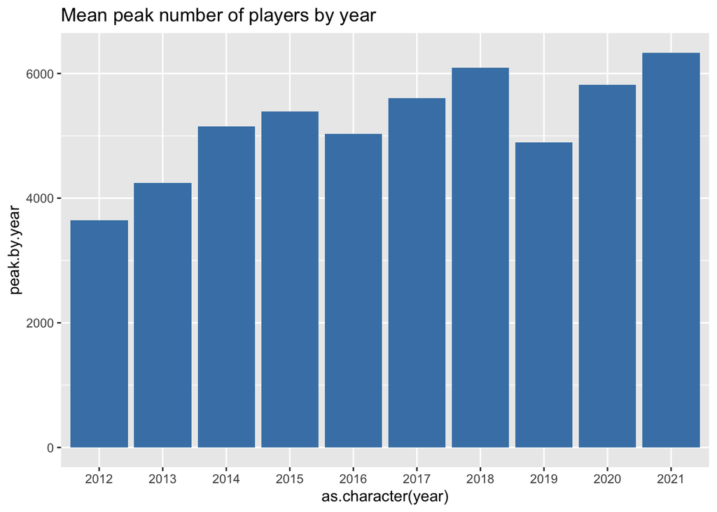

```r
library(dplyr)
grouped.year<-group_by(games.clean,year)
peak_by_year<-summarise(grouped.year,
          peak.by.year=mean(peak))
ggplot(data=peak_by_year, aes(x=as.character(year), y=peak.by.year)) +
  geom_bar(stat="identity", fill="steelblue")+ggtitle("Mean peak number of players by year")
```

Similarly, we also calculated mean peak number of players for games collected in each year. There’s also a clear trend of increase in mean peak number of players.

Specifically, I’M interested in records related with my favourite game Dota. I used regular expression to extract all records related with Dota.

```r
library(stringr)
dota<-games.clean[!is.na(str_extract(games.clean[,1],pattern = "Dota")),]
print(paste0("Number of records related with Dota: ",nrow(dota)))
```

```
## [1] "Number of records related with Dota: 123"
```

```r
dota.game.name<-paste(unique(dota[,1]),collapse = ",")
print(paste0("Kinds of dota games: ",dota.game.name))
```

```
## [1] "Kinds of dota games: Dota 2,Dota Underlords"
```

It turns out that there are 123 records are related with Dota. And actually two games belonging to Dota series,Dota2 and Dota Underlords ,are collected in this dataset. Specifically I’m more interested in records related with Dota2.

```r
dota2<-dota[dota[,1]=="Dota 2",]
dim(dota2)
```

```
## [1] 103   7
```

In total, 103 records about dota2 is collected in this dataset.We then sort this dota 2 data set according to its collection date.

```r
raw.date<-paste0(dota2[,3],"-","01","-",dota2[,2])
dota2[,"date"]<-as.Date(raw.date,"%B-%d-%Y")
dota2.sorted<-dota2[order(dota2$date),]
head(dota2.sorted)
```

```
##       gamename year     month       avg     gain   peak avg_peak_perc
## 83216   Dota 2 2012    August  55768.61  3047.56 108689       51.3103
## 82985   Dota 2 2012 September  61867.68  6099.07 118724       52.1105
## 82740   Dota 2 2012   October  75965.44 14097.77 171860       44.2019
## 82482   Dota 2 2012  November 101077.43 25111.99 169631       59.5866
## 82214   Dota 2 2012  December 121924.42 20846.99 213521       57.1018
## 81942   Dota 2 2013   January 147748.14 25823.72 260989       56.6109
##             date
## 83216 2012-08-01
## 82985 2012-09-01
## 82740 2012-10-01
## 82482 2012-11-01
## 82214 2012-12-01
## 81942 2013-01-01
```

Based on date-sorted dataset for Dota2.The very beginning record for dota is collected in August of 2012.

Next we plot the by-month average number of players for Dota 2

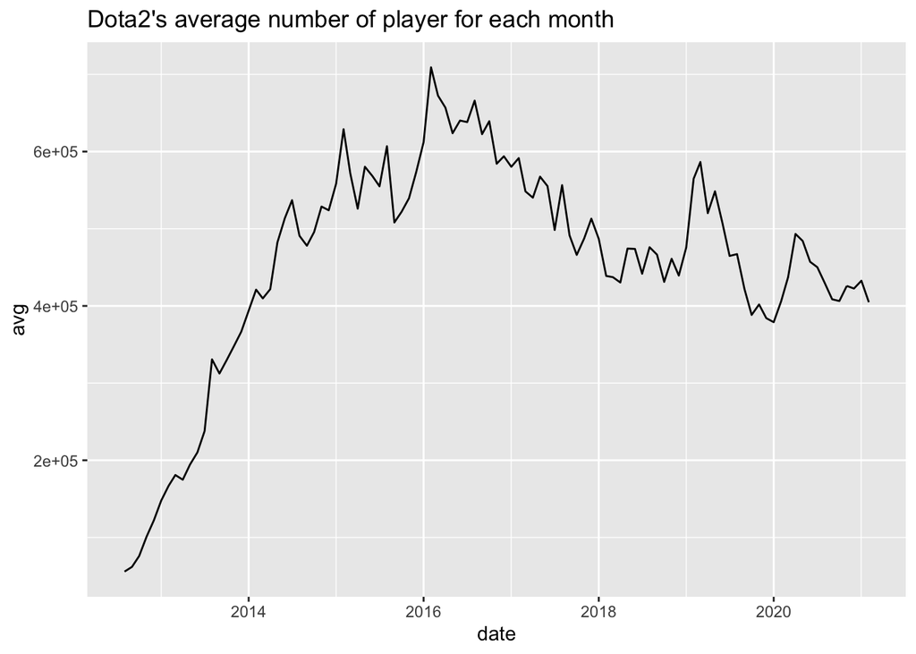

```r
ggplot(data=dota2.sorted, aes(x=date, y=avg)) +
  geom_line()+ggtitle("Dota2's average number of player for each month")
```

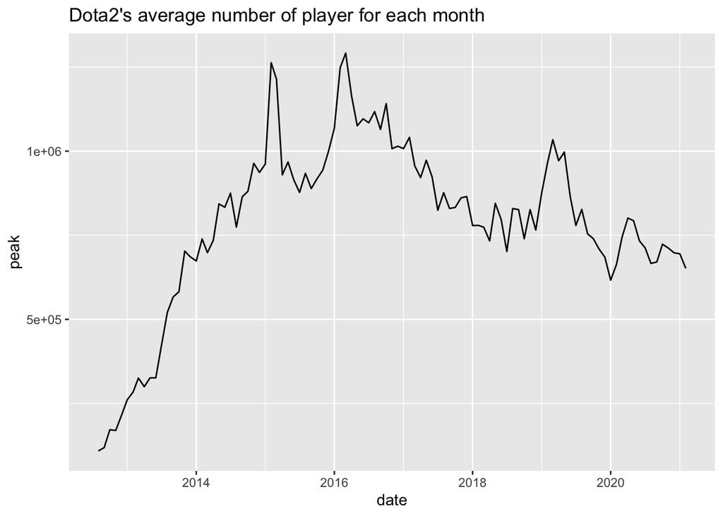

```r
ggplot(data=dota2.sorted, aes(x=date, y=peak)) +
  geom_line()+ggtitle("Dota2's average number of player for each month")
```

We first calculate net gain for each month by cumulative addition.

```r
dota2.sorted[,"monthly_net_gain"]<-cumsum(dota2.sorted$gain)
```

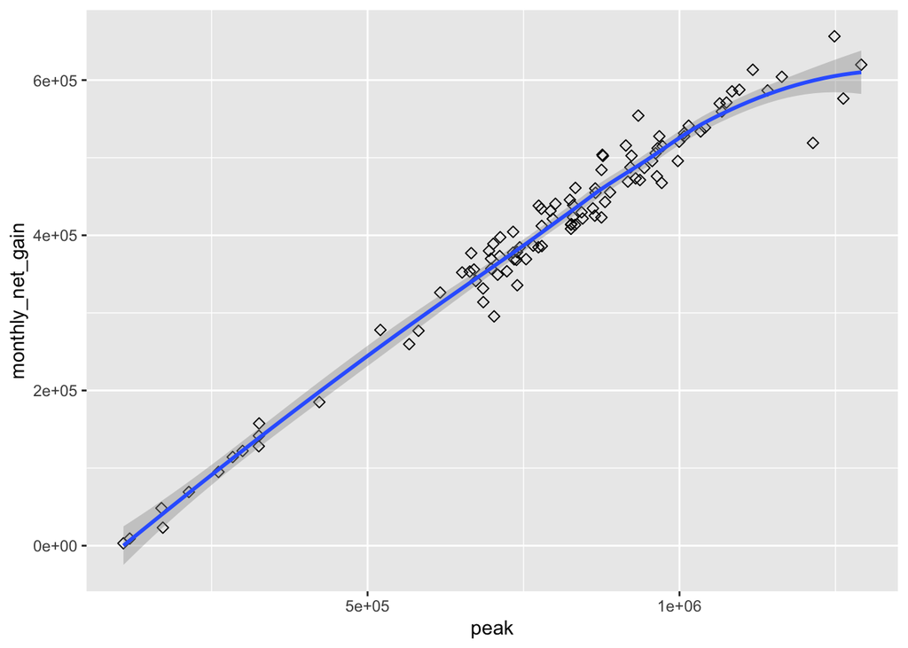

```r
ggplot(dota2.sorted, aes(x=peak, y=monthly_net_gain)) +
  geom_point(size=2, shape=23)+geom_smooth()
```

Based on plot above we can see a strong correlation between peak number of players and monthly net gain. Next we build a linear regression model for the above two variale

```r
y=dota2.sorted$monthly_net_gain
x=dota2.sorted$peak
mod<-lm(y~x)
summary(mod)
```

```
##
## Call:
## lm(formula = y ~ x)
##
## Residuals:
##     Min      1Q  Median      3Q     Max
## -120246  -12694   -1869   15497   70109
##
## Coefficients:
##               Estimate Std. Error t value Pr(>|t|)
## (Intercept) -3.331e+04  8.983e+03  -3.708 0.000342 ***
## x            5.540e-01  1.083e-02  51.150  < 2e-16 ***
## ---
## Signif. codes:  0 '***' 0.001 '**' 0.01 '*' 0.05 '.' 0.1 ' ' 1
##
## Residual standard error: 27430 on 101 degrees of freedom
## Multiple R-squared:  0.9628, Adjusted R-squared:  0.9625
## F-statistic:  2616 on 1 and 101 DF,  p-value: < 2.2e-16
```

The linear regression model is consistent with our observation the R squared between peak number of players and net gain is 0.9628.